# Mineração de Dados 2

Os tópicos abordados serão:

- *R Markdown*: criação de notebooks e documentos;
- instalação de pacotes;
- criação de funções;
- struturas de controle: `for`, `if`, `else`, `ifelse` `while`;
- análise bidimensional de dados: análise gráfica de variáveis qualitativas e quantitativas, ferramentas de visualização, medidas de associação.

# *R Markdown*

## Apresentação

- A versão original do *Markdown* foi criada em 2004 por Jonh Gruber como uma forma de converter texto em HTML, visando facilitar esta tarefa tornado-a mais legível.
- Entretanto, a ferramenta não era adequada para produção de documentos técnicos.
- John MacFarlane criou então um pacote chamando *Pandoc*, que permitia que documentos pudessem ser escritos em uma grande variedade de formatos.
- Documentos no formato *R Markdown* (RMD) foram primeiro introduzidos em 2012 no pacote *knitr* (Xie 2020) com o objetivo de introduzir códigos em *R* nos documentos do *Markdown*.
- O *knitr* suporta também vários outros formatos. Entre eles, o $\LaTeX$.
- O pacote RMarkdown (Allaire et al. 2020) foi introduzido em 2015 e se apoia no *knitr* e no *Pandoc*.
- Ele converte *R Markdown* em *Markdown*, produzindo documentos em diversos formatos: HTML, PDF, Word, entre outros.

$$\mbox{RMD} \xrightarrow{knitr} \mbox{MD} \xrightarrow{Pandoc} \mbox{Documento}$$

- O *R Markdown* pode ser utilizado para várias tarefas:
  - criação de documentos em diversos formatos diretamente do R;
  - criação de notebooks em que códigos são rodados diretamente de forma interativa;
  - criação de dashboards, apresentações, artigos, páginas web, entre outras tarefas.
- Deve-se instalar o pacote `rmarkdown`.

```r
install.packages("rmarkdown")
```

- Se não há software $\LaTeX$ intalado computador, pode-se instalar o pacote `tinytex`.

```r
install.packages("tinytex")
```

- Mais detalhes podem ser vistos em http://rmarkdown.rstudio.com.

## Utilização

- No *R markdown* você pode escrever livremente, inclusive utilizar algumas *tags* do HTML.
- Os códigos são escritos em *chunks*, que podem ser executados separadamente; ou seja, o *Rmarkdown* funciona como um notebook.
- O arquivo todo pode também ser compilado, produzindo um documento no formato escolhido.
- Equações em $\LaTeX$ podem ser escritas usando `$` ou `$$`, como em um arquivo .tex.
- Algumas opções básicas para os *chunks* são:
  - echo=FALSE: codigo executado, mas não mostrado no documento final;
  - include=FALSE: código executado, mas nem código nem output serão mostrados no documento final;
  - eval=FALSE: o código e mostrado, mas não executado.

# Exemplo 2 - Qualidade de vinhos

- O banco de dados contém informações sobre variações de vinhos tintos e brancos do vinho português “Vinho Verde”.
- Os dados podem ser obtidos em http://archive.ics.uci.edu/ml/datasets/Wine+Quality e já foram estudados por Cortez et al. (2009).
- As variáveis são:
  - *fixed acidity*;
  - *volatile acidity*
  - *citric acid*;
  - *residual sugar*;
  - *chlorides*;
  - *free sulfur dioxide*;
  - *total sulfur dioxide*
  - *density*
  - *pH*;
  - *sulphates*;
  - *alcohol*;
  - *quality (score between 0 and 10)* (baseada em dados sensoriais).

## Importando o banco de dados

Novamente, o primeiro passo para se trabalhar com um banco de dados no *R* é importá-lo.

### Arquivo com extensão .csv separado por ponto-e-vírgula

Vamos importar a base de dados de vinho tinto.

```r
red <- read.csv("http://im.ufrj.br/~joao/cienciadedados/winequality-red.csv",sep=";")
head(red)   # vislumbre dos dados
```

```
##   fixed.acidity volatile.acidity citric.acid residual.sugar chlorides
## 1           7.4             0.70        0.00            1.9     0.076
## 2           7.8             0.88        0.00            2.6     0.098
## 3           7.8             0.76        0.04            2.3     0.092
## 4          11.2             0.28        0.56            1.9     0.075
## 5           7.4             0.70        0.00            1.9     0.076
## 6           7.4             0.66        0.00            1.8     0.075
##   free.sulfur.dioxide total.sulfur.dioxide density   pH sulphates alcohol
## 1                  11                   34  0.9978 3.51      0.56     9.4
## 2                  25                   67  0.9968 3.20      0.68     9.8
## 3                  15                   54  0.9970 3.26      0.65     9.8
## 4                  17                   60  0.9980 3.16      0.58     9.8
## 5                  11                   34  0.9978 3.51      0.56     9.4
## 6                  13                   40  0.9978 3.51      0.56     9.4
##   quality
## 1       5
## 2       5
## 3       5
## 4       6
## 5       5
## 6       5
```

```r
names(red)   # # nomes das colunas do objeto (variáveis)
```

```
##  [1] "fixed.acidity"        "volatile.acidity"     "citric.acid"
##  [4] "residual.sugar"       "chlorides"            "free.sulfur.dioxide"
##  [7] "total.sulfur.dioxide" "density"              "pH"
## [10] "sulphates"            "alcohol"              "quality"
```

[output not shown]

[output not shown]

### Análise exploratória para os dados de vinho tinto (construindo histogramas)

Vamos fazer histogramas com todas as variáveis, que são quantitativas.

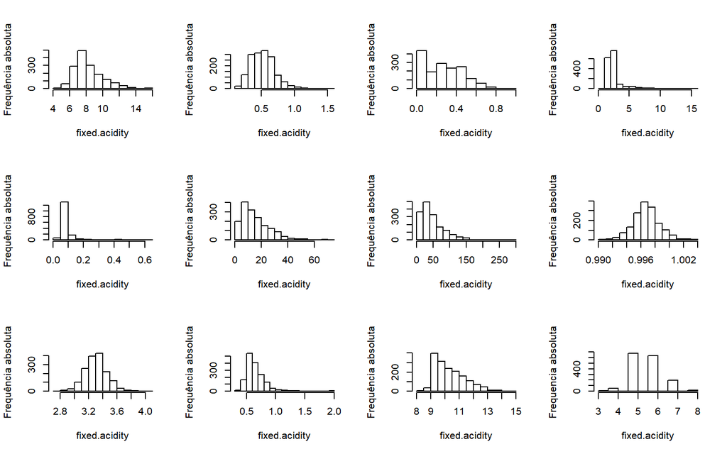

```r
par(mfrow=c(3,4))   # comando que permite configurar o ambiente gráfico antes da confecção
hist(red[,1],xlab=names(red)[1],ylab="Frequência absoluta",main="")
hist(red[,2],xlab=names(red)[1],ylab="Frequência absoluta",main="")
hist(red[,3],xlab=names(red)[1],ylab="Frequência absoluta",main="")
hist(red[,4],xlab=names(red)[1],ylab="Frequência absoluta",main="")
hist(red[,5],xlab=names(red)[1],ylab="Frequência absoluta",main="")
hist(red[,6],xlab=names(red)[1],ylab="Frequência absoluta",main="")
hist(red[,7],xlab=names(red)[1],ylab="Frequência absoluta",main="")
hist(red[,8],xlab=names(red)[1],ylab="Frequência absoluta",main="")
hist(red[,9],xlab=names(red)[1],ylab="Frequência absoluta",main="")
hist(red[,10],xlab=names(red)[1],ylab="Frequência absoluta",main="")
hist(red[,11],xlab=names(red)[1],ylab="Frequência absoluta",main="")
hist(red[,12],xlab=names(red)[1],ylab="Frequencia absoluta",main="")
```

*Será que há uma maneira menos trabalhosa de contruir este gráfico?*

## Comando `for`

- O comando `for` cria um ciclo a partir de um contador e o interrompe quando uma condição que depende do contador se torna falsa.

### Análise exploratória para os dados de vinho tinto (construindo histogramas)

Vamos construir os histogramas com todas as variáveis, mas agora utilizando o comando `for`.

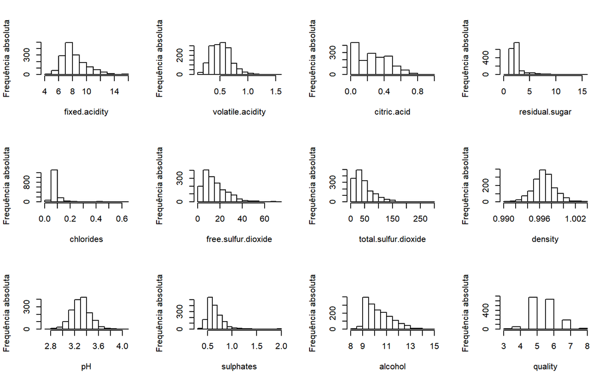

```r
par(mfrow=c(3,4))
n <- dim(red)[2]   # número de colunas
for(i in 1:n){
  hist(red[,i],xlab=names(red)[i],ylab="Frequência absoluta",main="")
}
```

Podemos calcular algumas medidas resumo-resumo utilizando o comando `summary`.

```r
summary(red)
```

```
##  fixed.acidity   volatile.acidity  citric.acid    residual.sugar
##  Min.   : 4.60   Min.   :0.1200   Min.   :0.000   Min.   : 0.900
##  1st Qu.: 7.10   1st Qu.:0.3900   1st Qu.:0.090   1st Qu.: 1.900
##  Median : 7.90   Median :0.5200   Median :0.260   Median : 2.200
##  Mean   : 8.32   Mean   :0.5278   Mean   :0.271   Mean   : 2.539
##  3rd Qu.: 9.20   3rd Qu.:0.6400   3rd Qu.:0.420   3rd Qu.: 2.600
##  Max.   :15.90   Max.   :1.5800   Max.   :1.000   Max.   :15.500
##    chlorides       free.sulfur.dioxide total.sulfur.dioxide    density
##  Min.   :0.01200   Min.   : 1.00       Min.   :  6.00       Min.   :0.9901
##  1st Qu.:0.07000   1st Qu.: 7.00       1st Qu.: 22.00       1st Qu.:0.9956
##  Median :0.07900   Median :14.00       Median : 38.00       Median :0.9968
##  Mean   :0.08747   Mean   :15.87       Mean   : 46.47       Mean   :0.9967
##  3rd Qu.:0.09000   3rd Qu.:21.00       3rd Qu.: 62.00       3rd Qu.:0.9978
##  Max.   :0.61100   Max.   :72.00       Max.   :289.00       Max.   :1.0037
##        pH          sulphates         alcohol         quality
##  Min.   :2.740   Min.   :0.3300   Min.   : 8.40   Min.   :3.000
##  1st Qu.:3.210   1st Qu.:0.5500   1st Qu.: 9.50   1st Qu.:5.000
##  Median :3.310   Median :0.6200   Median :10.20   Median :6.000
##  Mean   :3.311   Mean   :0.6581   Mean   :10.42   Mean   :5.636
##  3rd Qu.:3.400   3rd Qu.:0.7300   3rd Qu.:11.10   3rd Qu.:6.000
##  Max.   :4.010   Max.   :2.0000   Max.   :14.90   Max.   :8.000
```

Mas, suponha que queiramos criar um vetor com as médias, um com a mediana e um os desvios padrões amostrais para cada variável. Vamos utilizar o comando `for`.

```r
medias <- NULL   # declarando um vetor vazio
medianas <- NULL
dp <- NULL
for(i in 1:n){
    medias[i] <- mean(red[,i])
    medianas[i] <- median(red[,i])
    dp[i] <- sd(red[,i])
}
medias
```

```
##  [1]  8.31963727  0.52782051  0.27097561  2.53880550  0.08746654 15.87492183
##  [7] 46.46779237  0.99674668  3.31111320  0.65814884 10.42298311  5.63602251
```

```r
medianas
```

```
##  [1]  7.90000  0.52000  0.26000  2.20000  0.07900 14.00000 38.00000  0.99675
##  [9]  3.31000  0.62000 10.20000  6.00000
```

```r
dp
```

```
##  [1]  1.741096318  0.179059704  0.194801137  1.409928060  0.047065302
##  [6] 10.460156970 32.895324478  0.001887334  0.154386465  0.169506980
## [11]  1.065667582  0.807569440
```

Vamos combinar os vetores em um *data frame*.

```r
medidas <- data.frame(medias,medianas,dp)   # criando data frame
names(medidas) <- c("Média","Mediana","Desvio padrão")   # nomeando as colunas
row.names(medidas) <- names(red)   # nomeando as linhas
medidas
```

```
##                            Média  Mediana Desvio padrão
## fixed.acidity         8.31963727  7.90000   1.741096318
## volatile.acidity      0.52782051  0.52000   0.179059704
## citric.acid           0.27097561  0.26000   0.194801137
## residual.sugar        2.53880550  2.20000   1.409928060
## chlorides             0.08746654  0.07900   0.047065302
## free.sulfur.dioxide  15.87492183 14.00000  10.460156970
## total.sulfur.dioxide 46.46779237 38.00000  32.895324478
## density               0.99674668  0.99675   0.001887334
## pH                    3.31111320  3.31000   0.154386465
## sulphates             0.65814884  0.62000   0.169506980
## alcohol              10.42298311 10.20000   1.065667582
## quality               5.63602251  6.00000   0.807569440
```

## Análise bidimensional (variáveis quantitativas)

Inicialmente, queremos verificar se existe alguma relação aparente entre as características do vinho tinto e sua qualidade (*quality*).

Para este fim, podemos construir **gráficos de dispersão**.

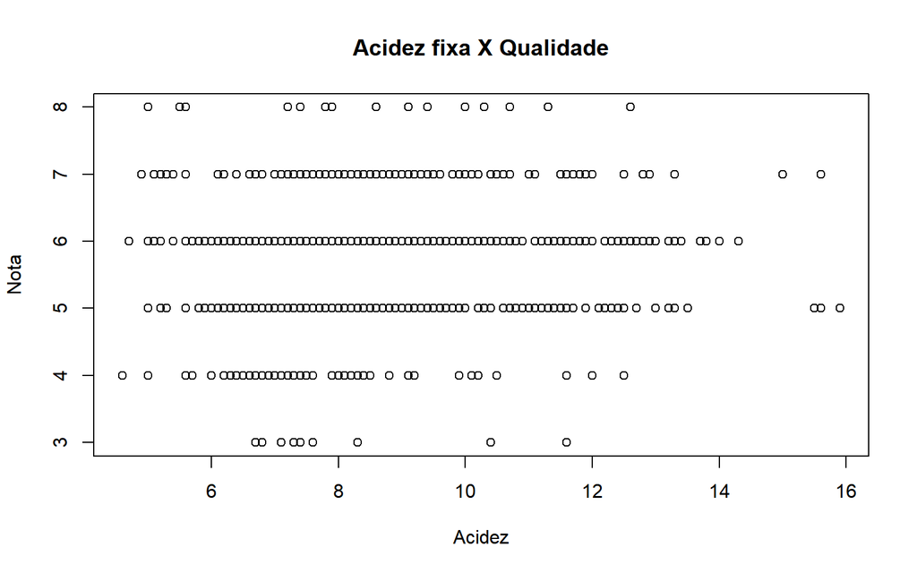

```r
plot(red[,1],red[,12],main="Acidez fixa X Qualidade",xlab="Acidez",ylab="Nota")
```

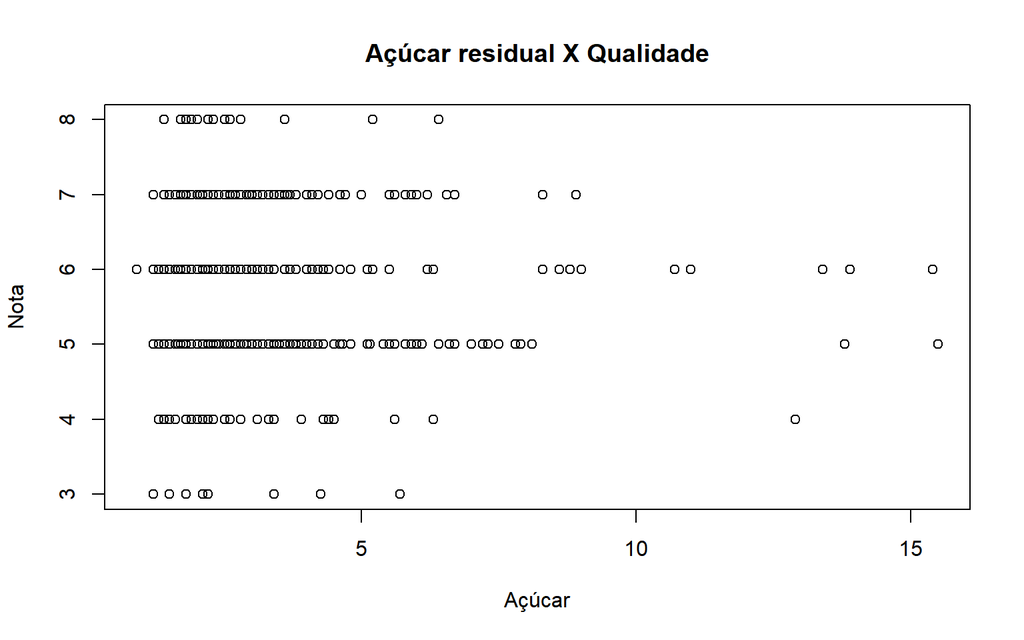

```r
plot(red[,4],red[,12],main="Açúcar residual X Qualidade",xlab="Açúcar",ylab="Nota")
```

Podemos ver todos, utilizando novamente o comando `for`.

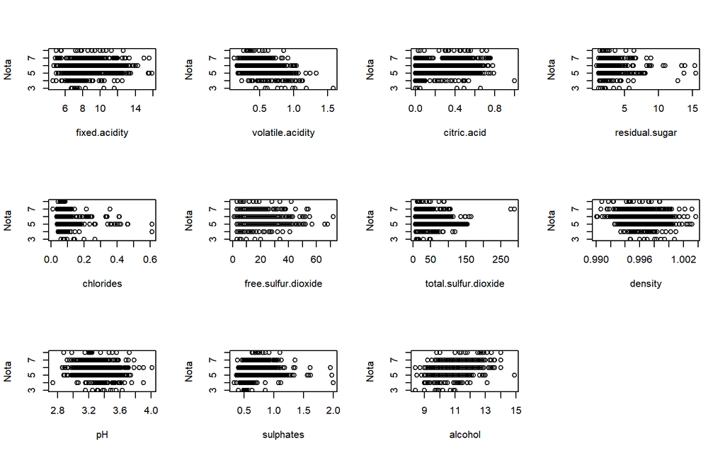

```r
par(mfrow=c(3,4))
for(i in 1:11){
    plot(red[,i],red[,12],xlab=names(red)[i],ylab="Nota")
}
```

Apesar da nota ser uma variável quantitativa, uma vez que ela é discreta e com poucas respostas, talvez seja mais adequado compará-la com as demais variáveis por meio de *box-plots*.

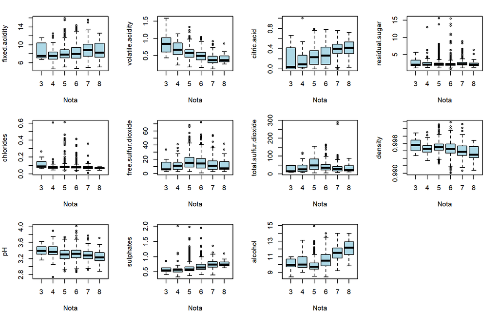

```r
par(mfrow=c(3,4),mar=c(4,4,2,2))   # par: dimensão; mar: tamanho da margem (b,l,t,r)
for(i in 1:11){
  boxplot(red[,i]~red[,12],ylab=names(red)[i],xlab="Nota",col="light blue")
}
```

Vamos verificar todas as variáveis de uma vez utilizando o comando `pairs()`.

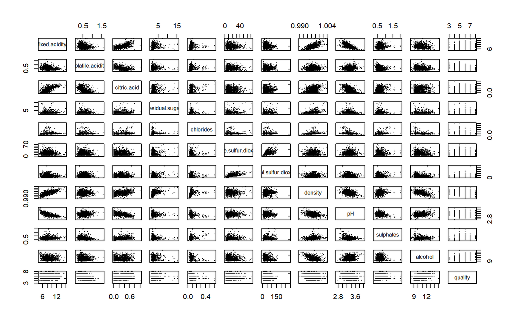

```r
pairs(red,pch=16,cex=0.2)   # pch: troca o tipo de ponto; cex: troca tamanho do ponto
```

Vamos focar em pares de variáveis particulares.

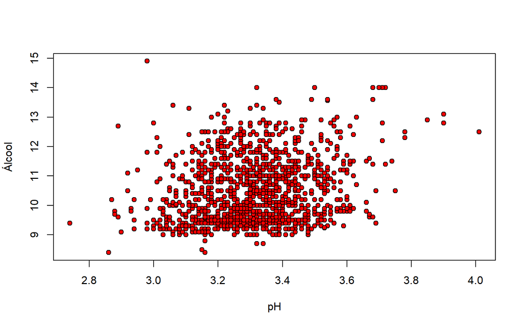

```r
plot(red[,9],red[,11],xlab="pH",ylab="Álcool",pch=21,col=1,bg=2)   # pch=21 permite preenchimento
```

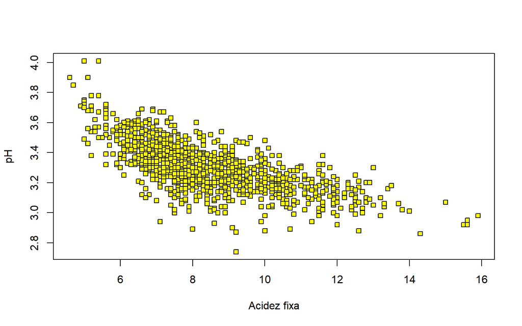

```r
plot(red[,1],red[,9],xlab="Acidez fixa",ylab="pH",pch=22,col=1,bg="yellow")   # pch=22 permite preenchimento
```

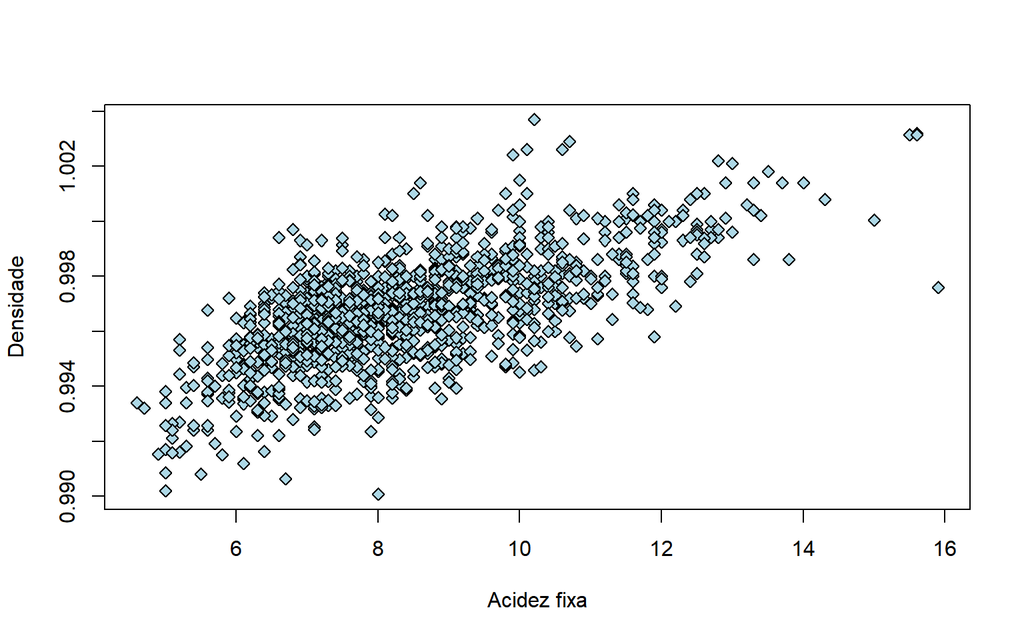

```r
plot(red[,1],red[,8],xlab="Acidez fixa",ylab="Densidade",pch=23,col=1,bg="light blue")   # pch=22 permite preenchimento
```

## Covariância e correlação

- Da mesma forma que existem medidas de centralidade, como a média e a mediana; medidas de dispersão, como a variância e o desvio padrão; existem medida que servem para medir o graus de associação entre variáveis.
- Em particular, para variáveis quantitativas, podemos utilizar a **covariância** amostral e o coeficiente de **correlação**.
- Ambas as medidas medem o grau de associação *linear* entre variáveis a partir de um um conjunto de dados em que as variáveis estão pareadas.
- Para um conjunto de dados $(x_1,y_1),(x_2,y_2),\dots,(x_n,y_n)$ a covariância amostral é definida como
  $$s_{xy} = \frac{1}{n-1}\sum_{i=1}^n (x_i - \overline x)(y_i - \overline y),$$
  em que $\overline x$ é a média de $x$ e $\overline y$ é a média de $y$.
- Valores positivos de $s_{xy}$ indicam associação linear positiva (caso seja linear) e valores negativos de $s_{xy}$ indicam associação linear negativa (caso seja linear).
- A covariância mede o quando as variáveis variam juntas.
- Entretanto, a covariância é uma medida sensível à escala dos dados.
- Uma medida adimensional, denominada coeficiente de correlação ou correlação, é definida a partir da covariância amostral como
  $$r_{xy} = \frac{s_{xy}}{s_xs_y} = \frac{\sum_{i=1}^n(x_i - \overline x)(y_i - \overline y)}{\sqrt{\sum_{i=1}^n(x_i - \overline x)^2\sum_{i=1}^n(y_i - \overline y)^2}},$$
  em que $s_x$ é o desvio padrão amostral de $x$ e $s_y$ é desvio padrão amostral de $y$.
- Temos que $-1 \leq r_{xy} \leq 1$. Quanto mais próximo o coeficiente está de $1$, maior a associação linear positiva; quanto mais próximo de $-1$, maior a associação linear negativa.

### Covariância e correlação para os dados de vinho tinto

Vamos selecionar alguns pares de variáveis.

```r
cov(red[,9],red[,11])   # covariancia amostral entre pH e álcool
```

```
## [1] 0.03383162
```

```r
cor(red[,9],red[,11])   # correlação entre pH e ácool
```

```
## [1] 0.2056325
```

```r
cov(red[,1],red[,9])   # covariancia amostral acidez fixa e pH
```

```
## [1] -0.1835857
```

```r
cor(red[,1],red[,9])   # correlação entre acidez fixa e pH
```

```
## [1] -0.6829782
```

```r
cov(red[,1],red[,8])   # covariancia amostral entre acidez fixa e densidade
```

```
## [1] 0.002195224
```

```r
cor(red[,1],red[,8])   # correlação entre acidez fixa e densidade
```

```
## [1] 0.6680473
```

Podemos calcular uma matriz de covariâncias ou correlações.

```r
cov(red)
```

```
##                      fixed.acidity volatile.acidity   citric.acid
## fixed.acidity          3.031416389    -7.985142e-02  0.2278200037
## volatile.acidity      -0.079851417     3.206238e-02 -0.0192716208
## citric.acid            0.227820004    -1.927162e-02  0.0379474831
## residual.sugar         0.281756262     4.841910e-04  0.0394342700
## chlorides              0.007678692     5.165869e-04  0.0018687248
## free.sulfur.dioxide   -2.800921493    -1.967359e-02 -0.1242521139
## total.sulfur.dioxide  -6.482345858     4.504257e-01  0.2276972740
## density                0.002195224     7.443665e-06  0.0001341746
## pH                    -0.183585704     6.494699e-03 -0.0162975823
## sulphates              0.054010092    -7.921434e-03  0.0103277145
## alcohol               -0.114421153    -3.860022e-02  0.0228151729
## quality                0.174423588    -5.647588e-02  0.0356118929
##                      residual.sugar     chlorides free.sulfur.dioxide
## fixed.acidity          0.2817562623  7.678692e-03       -2.800921e+00
## volatile.acidity       0.0004841910  5.165869e-04       -1.967359e-02
## citric.acid            0.0394342700  1.868725e-03       -1.242521e-01
## residual.sugar         1.9878971330  3.690176e-03        2.758611e+00
## chlorides              0.0036901759  2.215143e-03        2.738303e-03
## free.sulfur.dioxide    2.7586114522  2.738303e-03        1.094149e+02
## total.sulfur.dioxide   9.4164414790  7.338675e-02        2.297375e+02
## density                0.0009454109  1.782176e-05       -4.332504e-04
## pH                    -0.0186442890 -1.925745e-03        1.136531e-01
## sulphates              0.0013209414  2.961878e-03        9.159247e-02
## alcohol                0.0632189598 -1.109152e-02       -7.736984e-01
## quality                0.0156350457 -4.899545e-03       -4.279071e-01
##                      total.sulfur.dioxide       density            pH
## fixed.acidity               -6.482346e+00  2.195224e-03 -1.835857e-01
## volatile.acidity             4.504257e-01  7.443665e-06  6.494699e-03
## citric.acid                  2.276973e-01  1.341746e-04 -1.629758e-02
## residual.sugar               9.416441e+00  9.454109e-04 -1.864429e-02
## chlorides                    7.338675e-02  1.782176e-05 -1.925745e-03
## free.sulfur.dioxide          2.297375e+02 -4.332504e-04  1.136531e-01
## total.sulfur.dioxide         1.082102e+03  4.424727e-03 -3.376988e-01
## density                      4.424727e-03  3.562029e-06 -9.956395e-05
## pH                          -3.376988e-01 -9.956395e-05  2.383518e-02
## sulphates                    2.394710e-01  4.750962e-05 -5.146186e-03
## alcohol                     -7.209298e+00 -9.979518e-04  3.383162e-02
## quality                     -4.917237e+00 -2.666037e-04 -7.197822e-03
##                          sulphates       alcohol       quality
## fixed.acidity         5.401009e-02 -0.1144211534  0.1744235876
## volatile.acidity     -7.921434e-03 -0.0386002214 -0.0564758833
## citric.acid           1.032771e-02  0.0228151729  0.0356118929
## residual.sugar        1.320941e-03  0.0632189598  0.0156350457
## chlorides             2.961878e-03 -0.0110915178 -0.0048995449
## free.sulfur.dioxide   9.159247e-02 -0.7736984004 -0.4279070696
## total.sulfur.dioxide  2.394710e-01 -7.2092978950 -4.9172370717
## density               4.750962e-05 -0.0009979518 -0.0002666037
## pH                   -5.146186e-03  0.0338316166 -0.0071978223
## sulphates             2.873262e-02  0.0169067772  0.0344134084
## alcohol               1.690678e-02  1.1356473950  0.4097890108
## quality               3.441341e-02  0.4097890108  0.6521684000
```

```r
cor(red)
```

```
##                      fixed.acidity volatile.acidity citric.acid residual.sugar
## fixed.acidity           1.00000000     -0.256130895  0.67170343    0.114776724
## volatile.acidity       -0.25613089      1.000000000 -0.55249568    0.001917882
## citric.acid             0.67170343     -0.552495685  1.00000000    0.143577162
## residual.sugar          0.11477672      0.001917882  0.14357716    1.000000000
## chlorides               0.09370519      0.061297772  0.20382291    0.055609535
## free.sulfur.dioxide    -0.15379419     -0.010503827 -0.06097813    0.187048995
## total.sulfur.dioxide   -0.11318144      0.076470005  0.03553302    0.203027882
## density                 0.66804729      0.022026232  0.36494718    0.355283371
## pH                     -0.68297819      0.234937294 -0.54190414   -0.085652422
## sulphates               0.18300566     -0.260986685  0.31277004    0.005527121
## alcohol                -0.06166827     -0.202288027  0.10990325    0.042075437
## quality                 0.12405165     -0.390557780  0.22637251    0.013731637
##                         chlorides free.sulfur.dioxide total.sulfur.dioxide
## fixed.acidity         0.093705186        -0.153794193          -0.11318144
## volatile.acidity      0.061297772        -0.010503827           0.07647000
## citric.acid           0.203822914        -0.060978129           0.03553302
## residual.sugar        0.055609535         0.187048995           0.20302788
## chlorides             1.000000000         0.005562147           0.04740047
## free.sulfur.dioxide   0.005562147         1.000000000           0.66766645
## total.sulfur.dioxide  0.047400468         0.667666450           1.00000000
## density               0.200632327        -0.021945831           0.07126948
## pH                   -0.265026131         0.070377499          -0.06649456
## sulphates             0.371260481         0.051657572           0.04294684
## alcohol              -0.221140545        -0.069408354          -0.20565394
## quality              -0.128906560        -0.050656057          -0.18510029
##                          density          pH    sulphates     alcohol
## fixed.acidity         0.66804729 -0.68297819  0.183005664 -0.06166827
## volatile.acidity      0.02202623  0.23493729 -0.260986685 -0.20228803
## citric.acid           0.36494718 -0.54190414  0.312770044  0.10990325
## residual.sugar        0.35528337 -0.08565242  0.005527121  0.04207544
## chlorides             0.20063233 -0.26502613  0.371260481 -0.22114054
## free.sulfur.dioxide  -0.02194583  0.07037750  0.051657572 -0.06940835
## total.sulfur.dioxide  0.07126948 -0.06649456  0.042946836 -0.20565394
## density               1.00000000 -0.34169933  0.148506412 -0.49617977
## pH                   -0.34169933  1.00000000 -0.196647602  0.20563251
## sulphates             0.14850641 -0.19664760  1.000000000  0.09359475
## alcohol              -0.49617977  0.20563251  0.093594750  1.00000000
## quality              -0.17491923 -0.05773139  0.251397079  0.47616632
##                          quality
## fixed.acidity         0.12405165
## volatile.acidity     -0.39055778
## citric.acid           0.22637251
## residual.sugar        0.01373164
## chlorides            -0.12890656
## free.sulfur.dioxide  -0.05065606
## total.sulfur.dioxide -0.18510029
## density              -0.17491923
## pH                   -0.05773139
## sulphates             0.25139708
## alcohol               0.47616632
## quality               1.00000000
```

Vamos construir um **gráfico de imagem** utilizando as correlações.

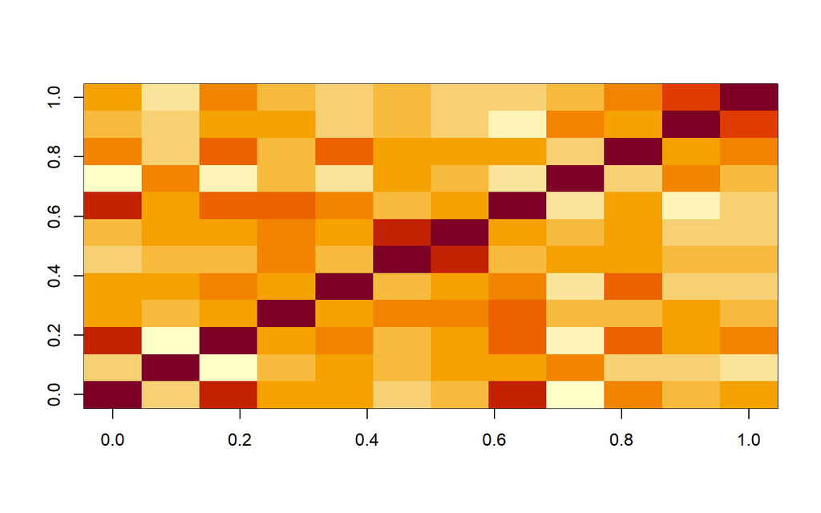

```r
corre <- cor(red)
image(corre)
```

Vamos melhorar o gráfico.

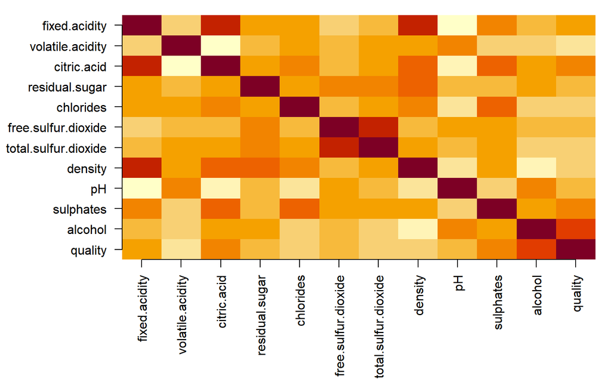

```r
par(mar=c(8,8,1,1))
image(1:12,1:12,corre[,12:1],axes=FALSE,xlab="",ylab="")
axis(1,at=1:12,labels=names(red),las=2)
axis(2,at=1:12,labels=names(red)[12:1],las=2)
```

Vamos modificar as cores.

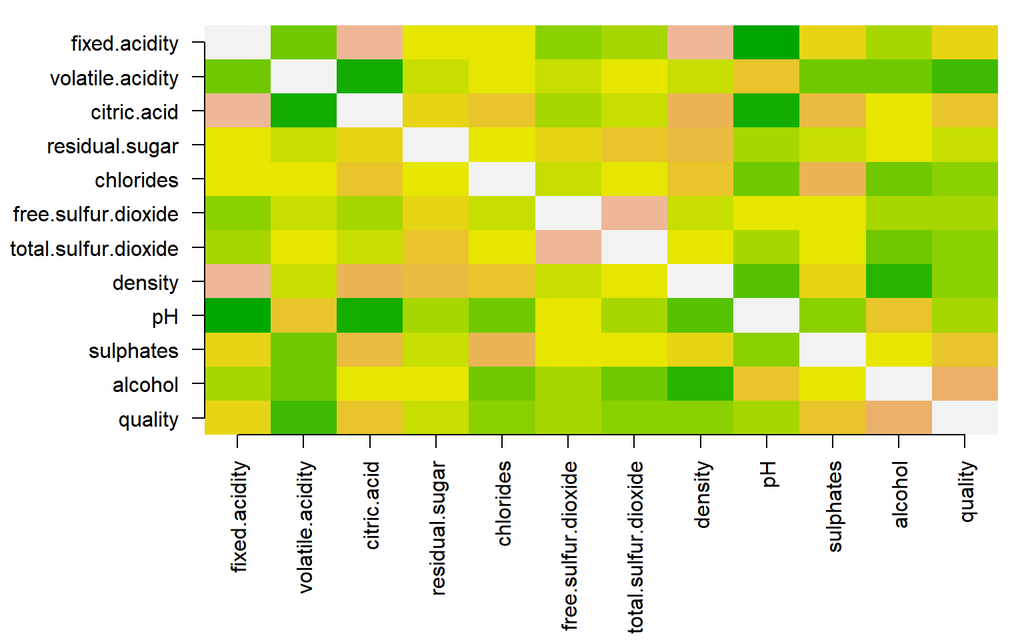

```r
par(mar=c(8,8,1,1))
image(1:12,1:12,corre[,12:1],axes=FALSE,xlab="",ylab="",col=terrain.colors(21))
axis(1,at=1:12,labels=names(red),las=2)
axis(2,at=1:12,labels=names(red)[12:1],las=2)
```

Algumas palhetas de cores: `heat.colors()`, `terrain.colors()`,`cm.colors()`.

## Instalando pacotes

- Os comandos do pacote *base* do *R* oferecem uma grande variedade de ferramentas para análise de dados.
- Entretanto, podem não ser suficientes para o que se deseja fazer.
- O *R* dispõe de muitos pacotes/bibliotecas com funções específicas.
- Tais pacotes podem ser baixados e instalados da internet ou instalados de arquivos locais no computador.
- No *R* e o *RStudio*, os pacotes podem ser instalados de forma intuitiva. Mas também podemos instalar um pacote utilizando um comando `install.packages()`.

### Instalando o pacote *corrplot*

O *corrplot* (Wei e Simko 2017) é um pacote com funções para visualização de matrizes de correlação.

```r
install.packages("corrplot")   # instalando o pacote
```

Para chamar um pacote, podemos utilizar os comandos `library()` ou `require()`. Somente assim, podemos utilizar as funções disponíveis.

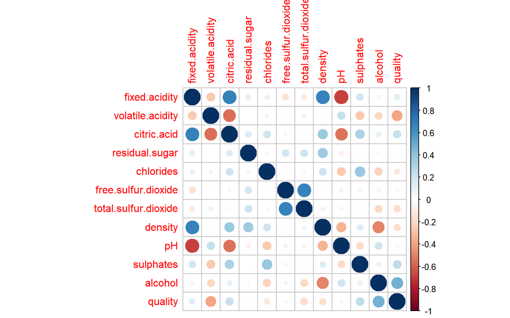

```r
library("corrplot")   # chamando o pacote
corrplot(corre)
```

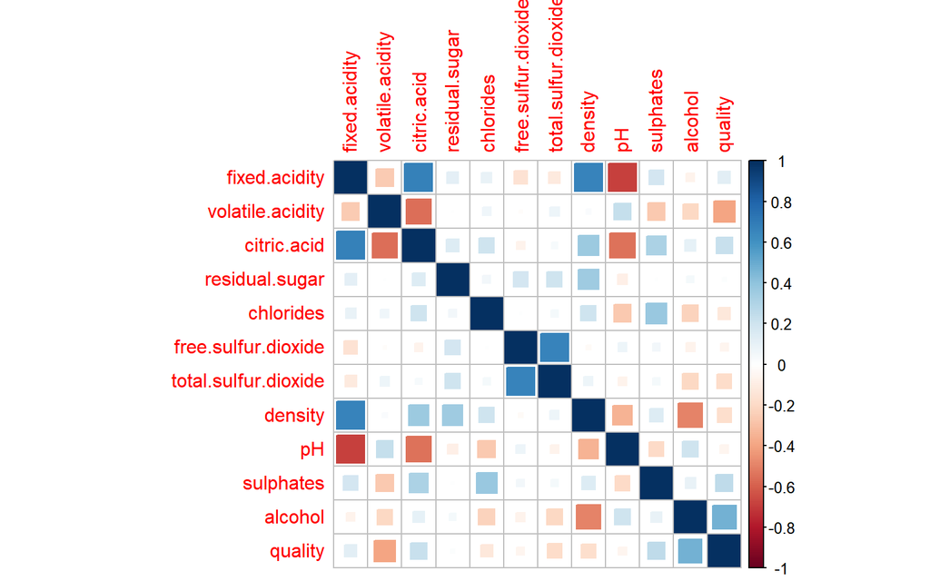

```r
corrplot(corre,method="square")
```

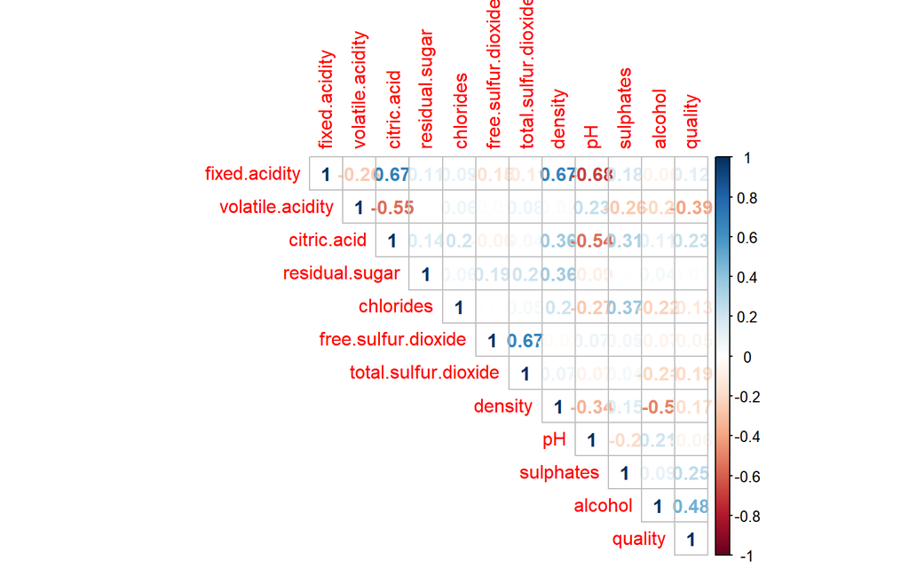

```r
corrplot(corre,method="number",type="upper")
```

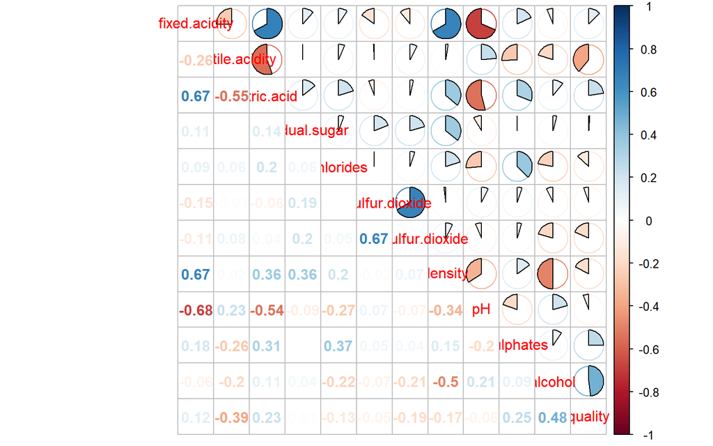

```r
corrplot.mixed(corre,lower="number",upper="pie")
```

### Instalando o pacote *scatterplot3d*

O pacote *scatterplot3d* (Ligges e Mächler 2003) fornece algumas funções para plotar gráficos tridimensonais.

```r
install.packages("scatterplot3d")   # instalando o pacote
```

Para “chamar” um pacote, podemos utilizar os comandos `library()` ou `require()`. Somente assim, podemos utilizar as funções disponíveis.

```r
library("scatterplot3d")   # chamando o pacote
```

Vamos plotar um gráfico de dispersão tridimensional comparando três variáveis do conjunto de dados de vinho tinto.

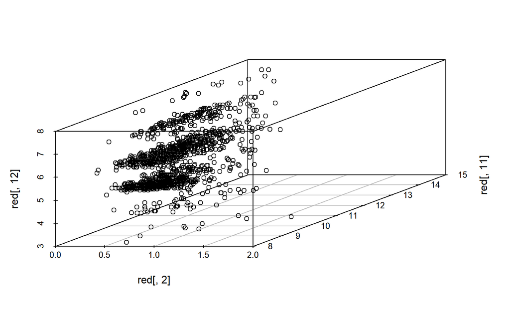

```r
scatterplot3d(red[,2],red[,11],red[,12])  # gráfico de dispersão 3d
```

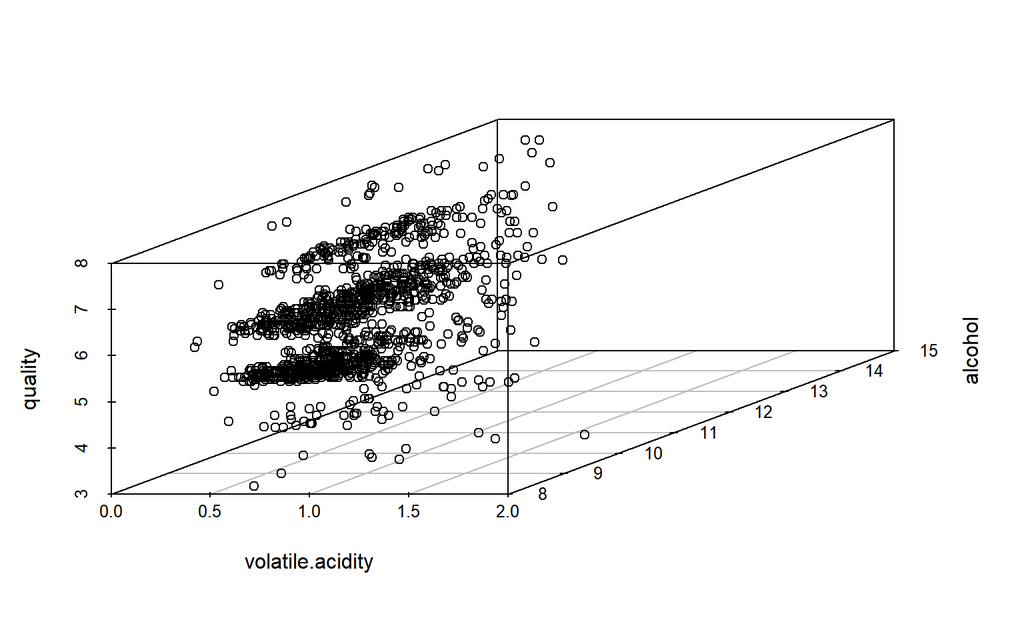

```r
scatterplot3d(red[,c(2,11,12)])   # outra forma
```

Vamos melhorar o gráfico.

```r
nota <- unique(red[,12])   # pegando valores únicos da nota (qualidade)
nota
```

```
## [1] 5 6 7 4 8 3
```

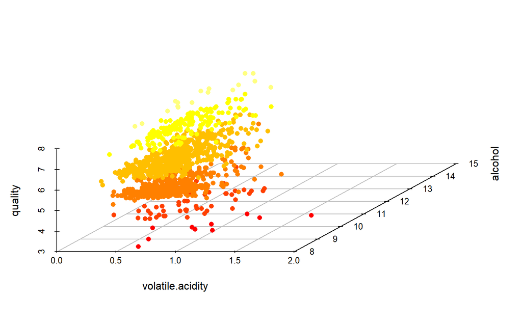

```r
nota <- sort(nota)   # organizando em ordem crescente
m <- length(nota)   # tamanho do vetor
cores1 <- heat.colors(m)   # criando palheta
cores2 <- NULL
for(i in 1:dim(red)[1]){
  cores2[i] <- cores1[nota==red[i,12]]
}
scatterplot3d(red[,c(2,11,12)],color=cores2,pch=16,angle=55,box=FALSE,scale.y=1)
```

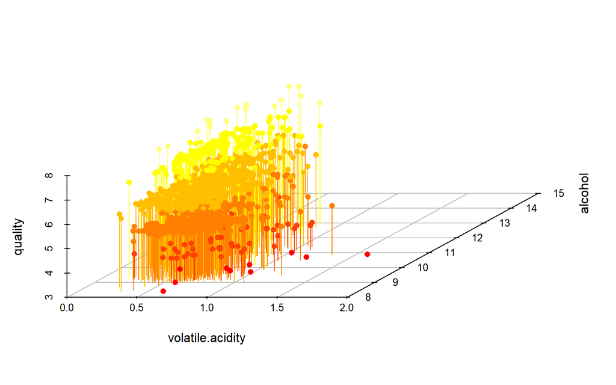

```r
scatterplot3d(red[,c(2,11,12)],color=cores2,pch=16,angle=55,box=FALSE,scale.y=1,type="h")
```

Utilizando uma ideia parecida, podemos fazer um gráfico bidimensional com três variáveis.

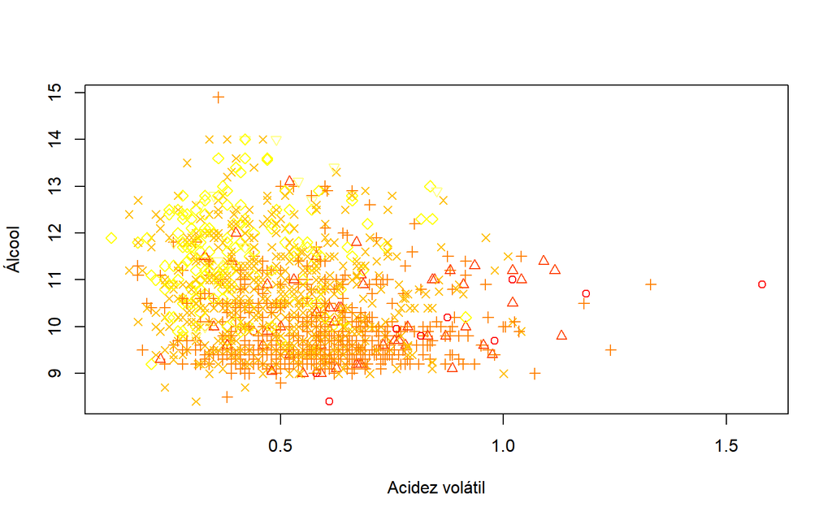

```r
cores1 <- heat.colors(m)   # criando palheta
pontos1 <- 1:m
cores2 <- NULL
pontos2 <- NULL
for(i in 1:dim(red)[1]){
  cores2[i] <- cores1[nota==red[i,12]]
  pontos2[i] <- pontos1[nota==red[i,12]]
}
plot(red[,2],red[,11],pch=pontos2,col=cores2,xlab="Acidez volátil",ylab="Álcool")
```

# Exemplo 3 - Performance de estudantes

- O banco de dados corresponde a variáveis associadas a alunos de duas escolas portuguesas.
- Os dados podem ser obtidos em http://archive.ics.uci.edu/ml/datasets/Student+Performance e foram estudados por Cortez e Silva (2008).
- As variáveis são:
  - *school - student’s school (binary: “GP” - Gabriel Pereira or “MS” - Mousinho da Silveira)*;
  - *sex - student’s sex (binary: “F” - female or “M” - male)*;
  - *age - student’s age (numeric: from 15 to 22)*;
  - *address - student’s home address type (binary: “U” - urban or “R” - rural)*;
  - *famsize - family size (binary: “LE3” - less or equal to 3 or “GT3” - greater than 3)*
  - *Pstatus - parent’s cohabitation status (binary: “T” - living together or “A” - apart)*
  - *Medu - mother’s education (numeric: 0 - none, 1 - primary education (4th grade), 2 – 5th to 9th grade, 3 – secondary education or 4 – higher education)*;
  - *Fedu - father’s education (numeric: 0 - none, 1 - primary education (4th grade), 2 – 5th to 9th grade, 3 – secondary education or 4 – higher education)*;
  - *Mjob - mother’s job (nominal: “teacher”, “health” care related, civil “services” (e.g. administrative or police), “at_home” or “other”)*;
  - *Fjob - father’s job (nominal: “teacher”, “health” care related, civil “services” (e.g. administrative or police), “at_home” or “other”)*;
  - *reason - reason to choose this school (nominal: close to “home”, school “reputation”, “course” preference or “other”)*;
  - *guardian - student’s guardian (nominal: “mother”, “father” or “other”)*
  - *traveltime - home to school travel time (numeric: 1 - <15 min., 2 - 15 to 30 min., 3 - 30 min. to 1 hour, or 4 - >1 hour)*;
  - *studytime - weekly study time (numeric: 1 - <2 hours, 2 - 2 to 5 hours, 3 - 5 to 10 hours, or 4 - >10 hours)*;
  - *failures - number of past class failures (numeric: n if 1<=n<3, else 4)*;
  - *schoolsup - extra educational support (binary: yes or no)*;
  - *famsup - family educational support (binary: yes or no)*;
  - *paid - extra paid classes within the course subject (Math or Portuguese) (binary: yes or no)*;
  - *activities - extra-curricular activities (binary: yes or no)*;
  - *nursery - attended nursery school (binary: yes or no)*;
  - *higher - wants to take higher education (binary: yes or no)*;
  - *internet - Internet access at home (binary: yes or no)*;
  - *romantic - with a romantic relationship (binary: yes or no)*;
  - *famrel - quality of family relationships (numeric: from 1 - very bad to 5 - excellent)*;
  - *freetime - free time after school (numeric: from 1 - very low to 5 - very high)*;
  - *goout - going out with friends (numeric: from 1 - very low to 5 - very high)*;
  - *Dalc - workday alcohol consumption (numeric: from 1 - very low to 5 - very high)*;
  - *Walc - weekend alcohol consumption (numeric: from 1 - very low to 5 - very high)*;
  - *health - current health status (numeric: from 1 - very bad to 5 - very good)*;
  - *absences - number of school absences (numeric: from 0 to 93)*;
  - *G1 - first period grade (numeric: from 0 to 20)*;
  - *G2 - second period grade (numeric: from 0 to 20)*;
  - *G3 - final grade (numeric: from 0 to 20, output target)*.

## Importando o banco de dados

- As notas, G1, G2 e G3, correspondem a duas disciplinas: Matemática e Português e estão divididas em dois bancos de dados.
- Primeiramente, vamos importar os bancos de dados separadamente.

### Arquivo com extensão .csv separado por ponto-e-vírgula

[output not shown]

[output not shown]

[output not shown]

[output not shown]

[output not shown]

[output not shown]

```r
mat <- read.csv("http://im.ufrj.br/~joao/cienciadedados/student-mat.csv",sep=";")
head(mat)   # vislumbre dos dados
names(mat)
dim(mat)
```

```r
por <- read.csv("http://im.ufrj.br/~joao/cienciadedados/student-por.csv",sep=";")
head(por)   # vislumbre dos dados
names(por)
dim(por)
```

## Mesclando bancos de dados

- Alguns alunos fizeram as duas provas: Matemática e Português.
- Queremos então juntar os dois bancos de dados em um único *data frame*.
- Para este fim, usaremos o comando `merge()`.

### Exemplo

```r
x1 <- c(10,10,8,7,6,8,10)   # nota 1
y1 <- c(9,9,7,7,7,9)   # nota 2

x2 <- c(2,1,6,4,5,3,7)   # identificação única do aluno
y2 <- c(5,6,4,3,2,1)   # identificação única do aluno

base1 <- data.frame(nota1=x1,aluno=x2)   # base 1
base2 <- data.frame(nota2=y1,aluno=y2)   # base 2

base <- merge(base1,base2,by="aluno")
base
```

```
##   aluno nota1 nota2
## 1     1    10     9
## 2     2    10     7
## 3     3     8     7
## 4     4     7     7
## 5     5     6     9
## 6     6     8     9
```

Como o aluno com identificação *7* aparece somente na primeira base, ele é retirado da base mesclada.

### Mesclando os bancos de dados dos alunos

Não há uma identificação única para cada aluno nos bancos de dados.

Desta forma, vamos utilizar mais de uma variável para identificá-los. Especificamente, iremos identificá-los considerando varios atributos idênticos.

```r
base <- merge(mat,por,by=c("school","sex","age","address","famsize","Pstatus","Medu","Fedu","Mjob","Fjob","reason","nursery","internet"))
head(base)
```

```
##   school sex age address famsize Pstatus Medu Fedu     Mjob     Fjob     reason
## 1     GP   F  15       R     GT3       T    1    1  at_home    other       home
## 2     GP   F  15       R     GT3       T    1    1    other    other reputation
## 3     GP   F  15       R     GT3       T    2    2  at_home    other reputation
## 4     GP   F  15       R     GT3       T    2    4 services   health     course
## 5     GP   F  15       R     GT3       T    3    3 services services reputation
## 6     GP   F  15       R     GT3       T    3    4 services   health     course
##   nursery internet guardian.x traveltime.x studytime.x failures.x schoolsup.x
## 1     yes      yes     mother            2           4          1         yes
## 2      no      yes     mother            1           2          2         yes
## 3     yes       no     mother            1           1          0         yes
## 4     yes      yes     mother            1           3          0         yes
## 5     yes      yes      other            2           3          2          no
## 6     yes      yes     mother            1           3          0         yes
##   famsup.x paid.x activities.x higher.x romantic.x famrel.x freetime.x goout.x
```

[output cut: 34 more lines]

```r
dim(base)
```

```
## [1] 382  53
```

Note que as variáveis que foram utilizadas para mesclar os bancos de dados aparecem somente uma vez e as que não foram, duas vezes.

## Comandos `if`, `else` e `ifelse`

- O comando `if` é utilizado para validar uma condição e então executar um comando de acordo com o resultado.
- O comando `else` é utilizado juntamente com o comando `if`.

As variáveis correspondentes às notas dos alunos, G1, G2 e G3, são numéricas.

### Criando uma variável binária

Vamos considerar somente a nota final: G3.

O aluno é considerado *aprovado* se a nota final é maior ou igual a 10; e reprovado, caso contrário.

```r
names(base)
```

```
##  [1] "school"       "sex"          "age"          "address"      "famsize"
##  [6] "Pstatus"      "Medu"         "Fedu"         "Mjob"         "Fjob"
## [11] "reason"       "nursery"      "internet"     "guardian.x"   "traveltime.x"
## [16] "studytime.x"  "failures.x"   "schoolsup.x"  "famsup.x"     "paid.x"
## [21] "activities.x" "higher.x"     "romantic.x"   "famrel.x"     "freetime.x"
## [26] "goout.x"      "Dalc.x"       "Walc.x"       "health.x"     "absences.x"
## [31] "G1.x"         "G2.x"         "G3.x"         "guardian.y"   "traveltime.y"
## [36] "studytime.y"  "failures.y"   "schoolsup.y"  "famsup.y"     "paid.y"
## [41] "activities.y" "higher.y"     "romantic.y"   "famrel.y"     "freetime.y"
## [46] "goout.y"      "Dalc.y"       "Walc.y"       "health.y"     "absences.y"
## [51] "G1.y"         "G2.y"         "G3.y"
```

```r
# forma 1
notamat <- base["G3.x"][,1]   # notas de matemática
notapor <- base["G3.y"][,1]   # notas de português
#forma 2
notamat <- base[,33]   # notas de matemática
notapor <- base[,53]   # notas de português
```

```r
n <- length(notamat)   # número de linhas da base mesclada
rmat <- rep("R",length=n)   # vetor de resultados em matemática
rpor <- rep("R",length=n)   # vetor de resultados em português
for(i in 1:n){
  if(notamat[i]>=10){
      rmat[i] <- "A"
  }
  if(notapor[i]>=10){
      rpor[i] <- "A"
  }
}
```

```r
freqmat <-table(rmat)
freqpor <- table(rpor)
freqmat
```

```
## rmat
##   A   R
## 255 127
```

```r
freqpor
```

```
## rpor
##   A   R
## 350  32
```

```r
freqmat <- as.numeric(freqmat)
freqpor <- as.numeric(freqpor)
```

Vamos analisar os resultados em Matemática.

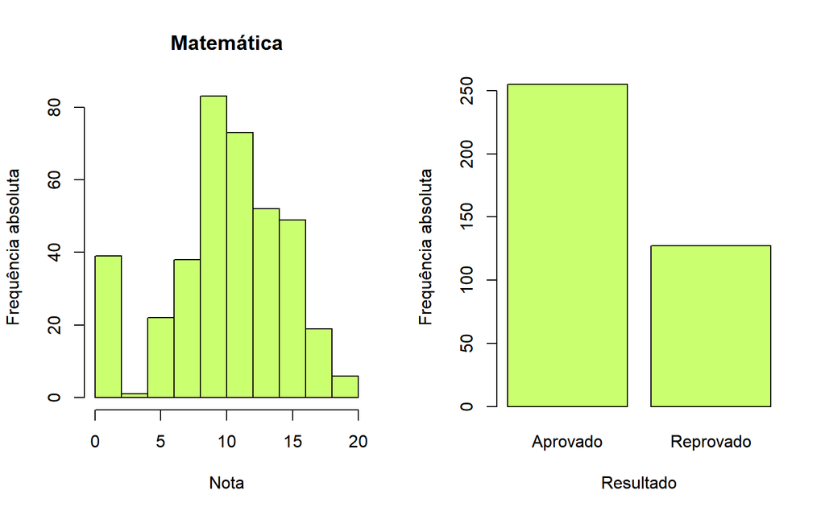

```r
par(mfrow=c(1,2))   # dois gráficos em uma linha
hist(notamat,xlab="Nota",ylab="Frequência absoluta",main="Matemática",col="darkolivegreen1")
barplot(freqmat,names.arg=c("Aprovado","Reprovado"),ylab="Frequência absoluta",main="",col="darkolivegreen1",xlab="Resultado")
```

Vamos analisar os resultados em Português.

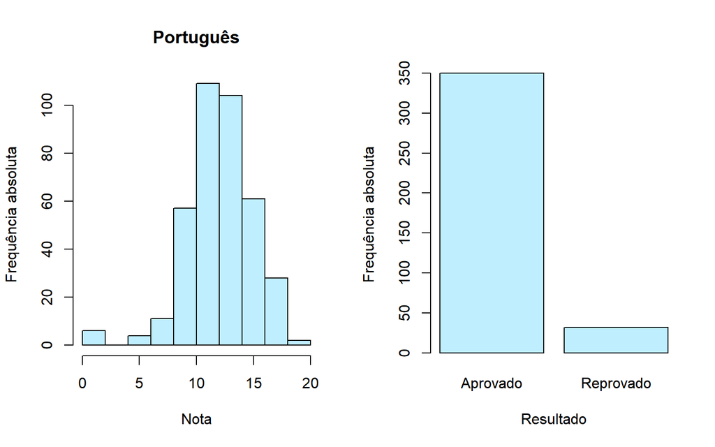

```r
par(mfrow=c(1,2))   # dois gráficos em uma linha
hist(notapor,xlab="Nota",ylab="Frequência absoluta",main="Português",col="lightblue1")
barplot(freqpor,names.arg=c("Aprovado","Reprovado"),ylab="Frequência absoluta",main="",col="lightblue1",xlab="Resultado")
```

Vamos verificar a associação entre as notas e resultados para as duas disciplinas: Matemática e Português.

```r
par(mfrow=c(1,2))   # dois gráficos em uma linha
plot(notamat,notapor,xlab="Nota em Matemática",ylab="Nota em Português",pch=16,col="dark blue")
tabela <- table(data.frame(rmat,rpor))
tabela   # tabela de contingência
```

```
##     rpor
## rmat   A   R
##    A 246   9
##    R 104  23
```

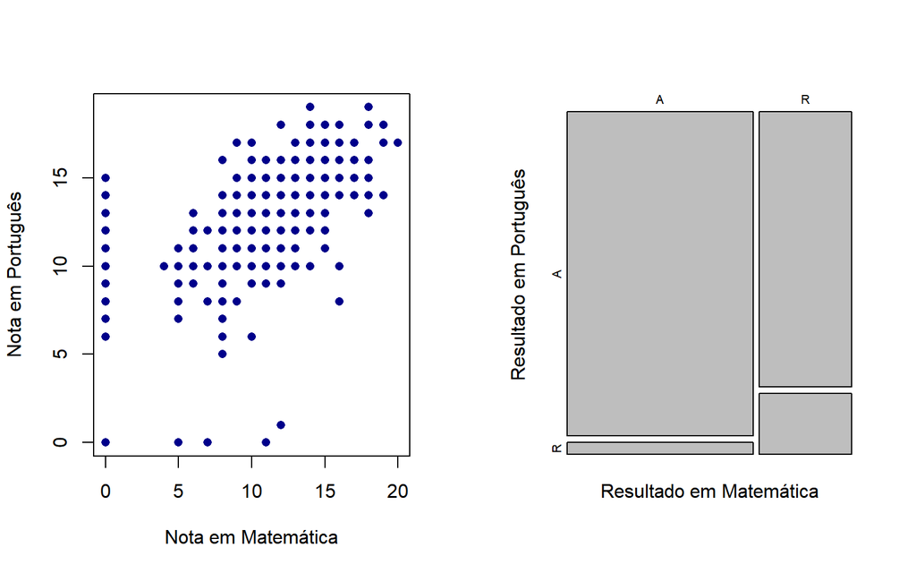

```r
plot(tabela,main="",xlab="Resultado em Matemática",ylab="Resultado em Português")
```

- Vamos agora classificar as notas em conceitos A, B e F de forma que
  - A: nota em [16,20];
  - B: nota em [10,15];
  - F: nota em [0,9].

### Criando as variáveis categóricas utilizando os comandos `if` e `else`

Utilizaremos os comandos `if` e `else` para construir vetores com os conceitos.

Começaremos com os conceitos em Matemática.

```r
cmat <- NULL
for(i in 1:n){
  if(notamat[i]>=16){
    cmat[i] <- "A"
  } else{
    if((notamat[i]<16)&(notamat[i]>=10)){
      cmat[i] <- "B"
    } else{
      if(notamat[i]<10){
        cmat[i] <- "F"
      }
    }
  }
}
table(cmat)
```

```
## cmat
##   A   B   F
##  42 213 127
```

### Criando as variáveis categóricas utilizando o comando `ifelse`

Podemos construir os vetor utilizando, alternativamente, uilizando o comando `ifelse`.

```r
cmat <- NULL
for(i in 1:n){
  cmat[i] <- ifelse(notamat[i]>=16,"A",ifelse((notamat[i]<16)&(notamat[i]>=10),"B","F"))
}
table(cmat)
```

```
## cmat
##   A   B   F
##  42 213 127
```

Vamos fazer o mesmo para os conceitos em Português.

```r
cpor <- NULL
for(i in 1:n){
  cpor[i] <- ifelse(notapor[i]>=16,"A",ifelse((notapor[i]<16)&(notapor[i]>=10),"B","F"))
}
table(cpor)
```

```
## cpor
##   A   B   F
##  58 292  32
```

```r
par(mfrow=c(1,2))   # dois gráficos em uma linha
tabela <- table(data.frame(cmat,cpor))
tabela   # tabela de contingência
```

```
##     cpor
## cmat   A   B   F
##    A  20  21   1
##    B  36 169   8
##    F   2 102  23
```

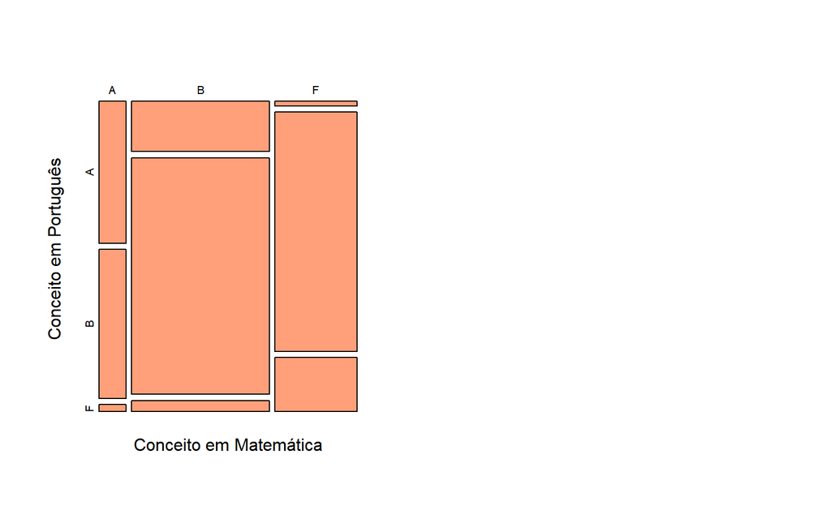

```r
plot(tabela,main="",xlab="Conceito em Matemática",ylab="Conceito em Português",col="lightsalmon")
```

## Análise bidimensional (variáveis qualitativas)

- Tabelas de contingência e gráficos como o anterior nos ajudam a enxergar se existe algum tipo de associação entre duas variáveis qualitativas.
- Podemos também lançar mão do teste $\chi^2$.
- Suponha que uma variável $A$ assuma valores $a_1,a_2,\dots,a_l$ e uma variável $B$ assuma valores $b_1,b_2,\dots,b_c$.
- As contagens de cada par $(a_i,b_j)$ podem ser apresentadas em uma *tabela de contingência*; vamos denotar a frequência absoluta do par $(a_i,b_j)$ como $o_{ij}$.
- A estatística $\chi^2$ (de Pearson) é definida como
  $$\chi^2 = \sum_{i=1}^l\sum_{j=1}^c \frac{(o_{ij}-e_{ij})^2}{e_{ij}},$$
  em que $e_{ij}$ é dado por
  $$e_{ij} = \frac{n_{i+}n_{+j}}{n},$$
  com $n_{i+}$ correspondendo ao total da linha $i$, $n_{+j}$ correspondendo ao total da coluna $j$ e $n$ correspondendo à contagem total.
- Os valores $e_{ij}$ correspondem às frequências esperadas sob a hipótese de independência entre $A$ e $B$.
- Assim, se $A$ e $B$ são independentes, espera-se que os valores $o_{ij}$ e $e_{ij}$ estejam próximos e, por sua vez, $\chi^2$ seja pequeno.
- Sob a hipótese de independência, $\chi^2$ tem distribuição qui-quadrado com $(l-1)(c-1)$ graus de liberdade.
- Se tal hipótese é rejeitada, podemos dizer que as variáveis estão correlacionadas.

### Verificando a associação entre os resultados (aprovado, reprovado) em Matemática e Português

```r
tabelar <- table(rmat,rpor)
tabelar   # tabela de contingência
```

```
##     rpor
## rmat   A   R
##    A 246   9
##    R 104  23
```

```r
tester <- chisq.test(tabelar)
tester
```

```
##
##  Pearson's Chi-squared test with Yates' continuity correction
##
## data:  tabelar
## X-squared = 21.622, df = 1, p-value = 3.321e-06
```

```r
names(tester)   # lista os membros do objeto
```

```
## [1] "statistic" "parameter" "p.value"   "method"    "data.name" "observed"
## [7] "expected"  "residuals" "stdres"
```

```r
tester$expected   # tabela de frequências esperadas sob independência
```

```
##     rpor
## rmat        A        R
##    A 233.6387 21.36126
##    R 116.3613 10.63874
```

### Verificando a associação entre os conceitos (A, B e F) em Matemática e Português

```r
tabelac <- table(cmat,cpor)
tabelac   # tabela de contingência
```

```
##     cpor
## cmat   A   B   F
##    A  20  21   1
##    B  36 169   8
##    F   2 102  23
```

```r
testec <- chisq.test(tabelac)
testec
```

```
##
##  Pearson's Chi-squared test
##
## data:  tabelac
## X-squared = 70.927, df = 4, p-value = 1.446e-14
```

```r
names(testec)   # lista os membros do objeto
```

```
## [1] "statistic" "parameter" "p.value"   "method"    "data.name" "observed"
## [7] "expected"  "residuals" "stdres"
```

```r
testec$expected   # tabela de frequências esperadas sob independência
```

```
##     cpor
## cmat         A         B         F
##    A  6.376963  32.10471  3.518325
##    B 32.340314 162.81675 17.842932
##    F 19.282723  97.07853 10.638743
```

Os membros de um objeto (caso haja) podem, dependendo de sua classe, ser acessados por meio do símbolo `$` e fornecendo seu nome.

Outra maneira de acessar um membro de um objeto é fornecendo sua posição entre dois colchetes.

```r
testec$statistic
```

```
## X-squared
##  70.92737
```

```r
testec[[1]]
```

```
## X-squared
##  70.92737
```

## Criando funções

- O *R* permite, além das funções em sua biblioteca, que o usuário crie suas próprias funções por meio da função `function()`.
- Uma vez definida, a função pode ser chamada como qualquer outra função ou comando interno do *R*.

### Função sem argumentos

```r
minhafuncao <- function(){   # declarando a função
  print("Esta função é um pouco inútil")
}

minhafuncao()   # executando a função
```

```
## [1] "Esta função é um pouco inútil"
```

```r
limpatudo <- function(){
  rm(list=ls())   # descartar os objetos do R
  gc()   # limpa o lixo da memória
  print("Limpinho!")
}

limpatudo()
```

```
## [1] "Limpinho!"
```

### Função com argumentos

Vamos criar uma função que calcula a distância entre dois pontos no plano cartesiano.

```r
distancia <- function(x,y){   # declarando a função
    d <- sqrt((x[1] - y[1])^2 + (x[2] - y[2])^2)
    return(d)
}

x <- c(1,2)
y <- c(4,5)

distancia(x,y)   # executando a função
```

```
## [1] 4.242641
```

Se na função não explicitamos o `return()`, o último valor avaliado é retornado.

Vamos melhoras a função da distância. Agora queremos que ele retorne um gráfico com os pontos.

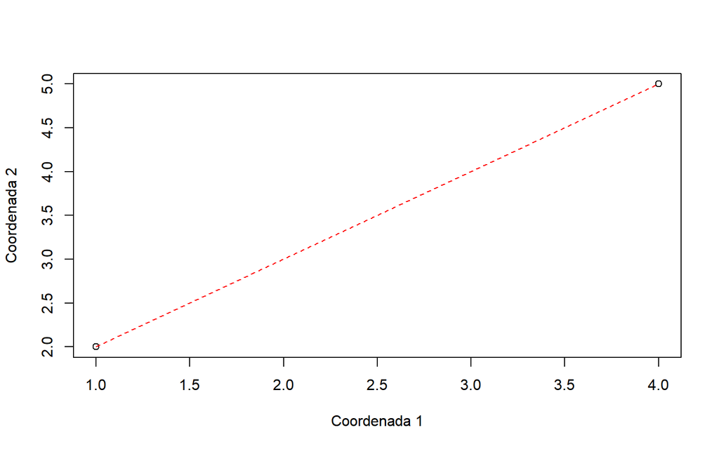

```
## [1] 4.242641
```

```r
distancia2.0 <- function(x,y,ponto=1,cor=1,tamanho=1){   # declarando a função
  plot(c(x[1],y[1]),c(x[2],y[2]),pch=ponto,col=cor,cex=tamanho,xlab="Coordenada 1",ylab="Coordenada 2")
  segments(x[1],x[2],y[1],y[2],lty=2,col=2)
  d <- sqrt((x[1] - y[1])^2 + (x[2] - y[2])^2)
  return(d)
}

x <- c(1,2)
y <- c(4,5)

distancia2.0(x,y)   # executando a função
```

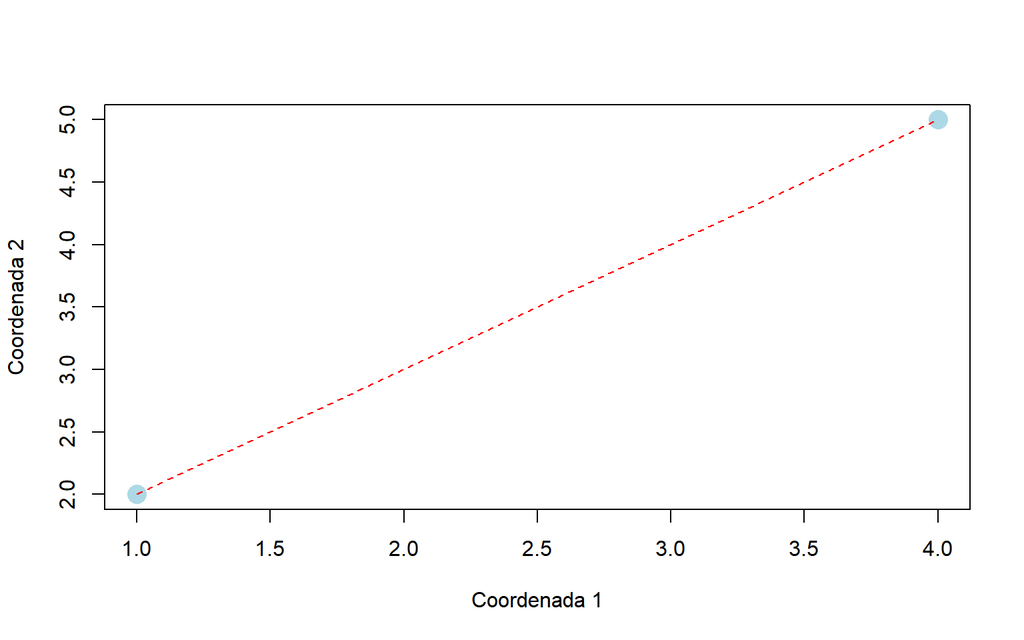

```
## [1] 4.242641
```

```r
distancia2.0(x,y,cor="light blue",ponto=16,tamanho=2)
```

### Função que calcula conceitos e medidas de associação entre as notas em Matemática e Português

Considerando os dados do exemplo anterior, vamos agora criar uma função que retorna a correlação, o conceito e o valor da estatística $\chi^2$ para dois vetores de notas em uma lista.

Uma lista pode ser criada por meio da função`list()`.

```r
conceito <- function(x,y){  # declarando a função
  conc1 <- NULL
  conc2 <- NULL
  for(i in 1:length(x)){
    conc1[i] <- ifelse(x[i]>=16,"A",ifelse((x[i]<16)&(x[i]>=10),"B","F"))
    conc2[i] <- ifelse(y[i]>=16,"A",ifelse((y[i]<16)&(y[i]>=10),"B","F"))
  }
  corre <- cor(x,y)
  teste <- chisq.test(table(conc1,conc2))
  qui <- teste$statistic
  return(list("conceito"=cbind(conc1,conc2),"correlacao"=corre,"quiquadrado"=qui))
}

sumario <- conceito(notamat,notapor)   # executando a função
class(sumario)
```

```
## [1] "list"
```

```r
names(sumario)
```

```
## [1] "conceito"    "correlacao"  "quiquadrado"
```

Como antes, podemos acessar os membros de uma lista pelo nome usando o símbolo `$` ou por sua posição usando dis colchetes.

```r
conceitos <- sumario$conceito
head(conceitos)
```

```
##      conc1 conc2
## [1,] "B"   "B"
## [2,] "F"   "B"
## [3,] "B"   "B"
## [4,] "F"   "B"
## [5,] "B"   "B"
## [6,] "B"   "B"
```

```r
conceitos <- sumario[[1]]
head(conceitos)
```

```
##      conc1 conc2
## [1,] "B"   "B"
## [2,] "F"   "B"
## [3,] "B"   "B"
## [4,] "F"   "B"
## [5,] "B"   "B"
## [6,] "B"   "B"
```

```r
sumario$correlacao
```

```
## [1] 0.4803494
```

```r
sumario[[2]]
```

```
## [1] 0.4803494
```

```r
sumario$quiquadrado
```

```
## X-squared
##  70.92737
```

```r
sumario[[3]]
```

```
## X-squared
##  70.92737
```

### Função que constrói um polígono de frequências

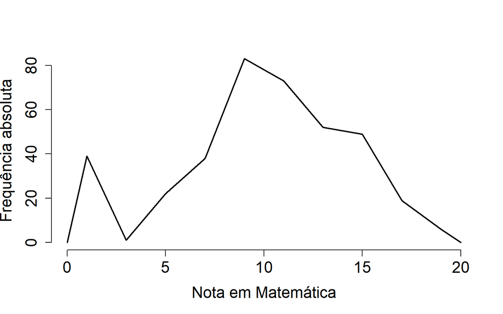

```r
polyfreq <- function(x,bty="n",cex.axis=1.5,cex.lab=1.5,lwd=2,xlab="x",ylab="y"){   # função que faz poligono de frequencias
  a <- hist(x,plot=FALSE)
  mid <- a$mids
  count <- a$counts
  n <- length(mid)
  inf <- mid[1] - (mid[2] - mid[1])/2
  sup <- mid[n] + (mid[n] - mid[n-1])/2
  xgrid <- c(inf,mid,sup)
  ygrid <- c(0,count,0)
  m <- length(xgrid)
  plot(mid,count,xlim=c(min(xgrid),max(xgrid)),ylim=c(0,max(ygrid)),type="n",cex.axis=cex.axis,cex.lab=cex.lab,bty=bty,xlab=xlab,ylab=ylab)
  for(i in 1:(m-1)){
    segments(xgrid[i],ygrid[i],xgrid[i+1],ygrid[i+1],lwd=lwd)
  }
}

polyfreq(notamat,ylab="Frequência absoluta",xlab="Nota em Matemática")
```

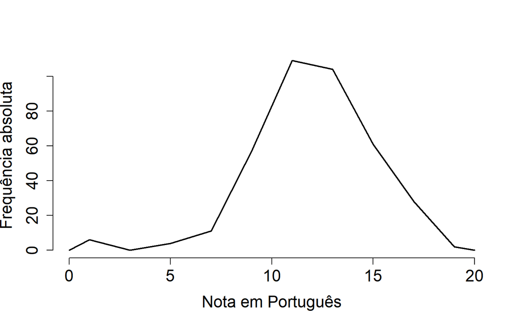

```r
polyfreq(notapor,ylab="Frequência absoluta",xlab="Nota em Português")
```

## Comando `while`

- O comando `while` cria um ciclo a partir de uma condição e interrompe este ciclo quando a condição se torna falsa.

### Nova função que calcula conceitos e medidas de associação entre as notas em Matemática e Português

```r
conceito <- function(x,y){  # declarando a função
  conc1 <- NULL
  conc2 <- NULL
  i <- 1
  while(i<=length(x)){   # trocando o for pelo while
    conc1[i] <- ifelse(x[i]>=16,"A",ifelse((x[i]<16)&(x[i]>=10),"B","F"))
    conc2[i] <- ifelse(y[i]>=16,"A",ifelse((y[i]<16)&(y[i]>=10),"B","F"))
    i <- i + 1
  }
  corre <- cor(x,y)
  teste <- chisq.test(table(conc1,conc2))
  qui <- teste$statistic
  return(list("conceito"=cbind(conc1,conc2),"correlacao"=corre,"quiquadrado"=qui))
}

sumario <- conceito(notamat,notapor)
sumario
```

```
## $conceito
##        conc1 conc2
##   [1,] "B"   "B"
##   [2,] "F"   "B"
##   [3,] "B"   "B"
##   [4,] "F"   "B"
##   [5,] "B"   "B"
##   [6,] "B"   "B"
##   [7,] "F"   "B"
##   [8,] "F"   "B"
##   [9,] "A"   "B"
##  [10,] "B"   "B"
##  [11,] "B"   "B"
##  [12,] "F"   "B"
##  [13,] "B"   "B"
```

[output cut: 376 more lines]

# Referências

Allaire, J. J., Y. Xie, J. McPherson, J. Luraschi, K. Ushey, A. Atkins, H. Wickham, J. Cheng, W. Chang, e R. Iannone. 2020. *rmarkdown: Dynamic Documents for R*. https://github.com/rstudio/rmarkdown.

Cortez, P., A. Cerdeira, F. Almeida, T. Matos, e J. Reis. 2009. “Modeling wine preferences by data mining from physicochemical properties”. *Decision Support Systems* 47: 547–53.

Cortez, P., e A. M. G. Silva. 2008. “Using data mining to predict secondary school student performance”.

Ligges, U., e M. Mächler. 2003. “Scatterplot3d - an R Package for Visualizing Multivariate Data”. *Journal of Statistical Software* 8 (11): 1–20. http://www.jstatsoft.org.

Wei, T., e V. Simko. 2017. *R package "corrplot": Visualization of a Correlation Matrix*. https://github.com/taiyun/corrplot.

Xie, Y. 2020. *knitr: A General-Purpose Package for Dynamic Report Generation in R*. https://yihui.org/knitr/.